# MidTerm - INST 447 - Spring 2023

Your Name:

## Instructions

This MidTerm is to be completed individually. You may use any other reasonable resource to complete these tasks, with the exception of other people. You may use your notes, Internet resources, the course site, just not other students or individuals. The exlusion of other people includes the *asking* questions on StackOverflow or similar forums. However, you may refer answers to previously asked questions on those sites. Using ChatGPT or similiar AI code generation tools is not permitted. Out of an abundance of caution, disable your Tabnine or Copilot plugin for this exam.

There are a total of 50 points available. Each question is section is worth 2 points and there are 25 questions. Questions are marked with the "FILL-IN". There are several text-only answers, those are in Markdown cells.

This MidTerm Exam is take home and timely completion is required. Late submissions will be penalized to the following scale:

> less than 24 hours: 20% deduction  
> greater than 24 hours: Automatic 0

Make sure that you read the exam to the end. This is not one of those tricks where the last question tells you to ignore all the rest. Instead, several question build upon the previous one, in these cases you may better understand the current questions task by knowing what the next question is expecting.

### Where is the data?

The data files are all in the data folder.

### Answering Questions and Entering Text

This is a Jupyter Notebook file, which allows you to choose whether a cell contains *Python code* or *formated text*. To respond to a question that requires a text and already contains *formated text* double-click on the text near the "FILL-IN" to be able to edit the cell.

To answer a code question, enter your code that completes the requested task in the cell provided. Do not feel like you are not limited to one line of code. You may also add cells (though make sure that it is clear what cell answers the questions).

Using the inappropriate type of cell for a response will result in point deductions.

### Honor Pledge

The University has a nationally recognized Honor Code, administered by the Student Honor Council. The Student Honor Council proposed and the University Senate approved an Honor Pledge. The University of Maryland Honor Pledge reads:

> *I pledge on my honor that I have not given or received any unauthorized assistance on this assignment/examination.*

Please type the honor pledge into the space below. Students who fail to write and sign the Pledge will be asked to confer with the instructor.

# Honor Pledge _ Sang Hwa Lee

## I pledge on my honor that I have not given or received any unauthorized assistance on this assignment/examination.

```python
import pandas as pd
import numpy as np
import matplotlib.pyplot as plt
%matplotlib inline
```

There are two files. One called "voting.csv" the other is called "gender.csv". Create 2 data frames. One called `voting` and the other called `gender` and fill them with the data from the corresponding file.  
Use relative paths to load load the files.

**(1)** Load 'voting.csv' from the data folder into a DataFrame called `voting`

```python
voting = pd.read_csv('voting.csv')
```

```python
# Print the first few rows of the voting DataFrame
voting.head(5)
```

|  | Year | 18-24 Voted | 18-24 Registered | 25-44 Voted | 25-44 Registered | 45-64 Voted | 45-64 Registered | 65 and over Voted | 65 and over Registered | Total Voted | Total Registered |
| --- | --- | --- | --- | --- | --- | --- | --- | --- | --- | --- | --- |
| 0 | 1980 | ? | ? | ? | ? | ? | ? | ? | ? | ? | ? |
| 1 | 1982 | 7139000 | 12227000 | 30343000 | 41103000 | 27491000 | 33422000 | 15336000 | 19245000 | 80309000 | 105997000 |
| 2 | 1984 | ? | ? | ? | ? | ? | ? | ? | ? | ? | ? |
| 3 | 1986 | 5782000 | 11109000 | 31003000 | 45790000 | 26305000 | 33528000 | 16865000 | 21300000 | 79955000 | 111727000 |
| 4 | 1988 | 9254000 | 12321000 | 42018000 | 49066000 | 31134000 | 34622000 | 19818000 | 22580000 | 102224000 | 118589000 |

**(2)** Load 'gender.csv' from the data folder into a DataFrame called `gender`

```python
gender = pd.read_csv('gender.csv')
```

```python
# This is showing dataframe

gender.head(5)
```

|  | Year | Male | Female | Total Voted |
| --- | --- | --- | --- | --- |
| 0 | 1980 | 43753000 | 49312000 | 93065000 |
| 1 | 1982 | 38025000 | 42285000 | 80309000 |
| 2 | 1984 | 47354000 | 54524000 | 101878000 |
| 3 | 1986 | 37729000 | 42225000 | 79955000 |
| 4 | 1988 | ? | ? | ? |

**(3)** Perform Level 1 data cleaning on the *gender* dataframe.  
Make sure that any missing values are converted to NaN.  
Add comments that identify the aspect of Level 1 that a line or lines of code fixes.

```python
# Replace missing values '?' with NaN
gender.replace('?', np.nan, inplace=True)

# Display the first few rows of the gender DataFrame after cleaning
gender.head(5)
```

|  | Year | Male | Female | Total Voted |
| --- | --- | --- | --- | --- |
| 0 | 1980 | 43753000 | 49312000 | 93065000 |
| 1 | 1982 | 38025000 | 42285000 | 80309000 |
| 2 | 1984 | 47354000 | 54524000 | 101878000 |
| 3 | 1986 | 37729000 | 42225000 | 79955000 |
| 4 | 1988 | NaN | NaN | NaN |

**(4)** *gender* contains 18 observations and 4 variables. The variables' data is numerical, but there may be missing values.

Verify this information about the *gender* data frame using Pandas.

```python
# Converting the 'Male', 'Female', and 'Total Voted' columns to float data type
gender['Male'] = gender['Male'].replace('?', np.nan).astype(float)
gender['Female'] = gender['Female'].replace('?', np.nan).astype(float)
gender['Total Voted'] = gender['Total Voted'].replace('?', np.nan).astype(float)

# Verifying the updated data types and missing values
print("Data types:")
print(gender.dtypes)
print("\nMissing values:")
print(gender.isna().sum())
```

```
Data types:
Year             int64
Male           float64
Female         float64
Total Voted    float64
dtype: object

Missing values:
Year           0
Male           4
Female         4
Total Voted    4
dtype: int64
```

**(5)** Perform Level 1 data cleaing on the *voting* dataframe.  
Make sure that any missing values are coverted to NaN. Add comments that identify the aspect of Level 1 that a line or lines of code fixes.

```python
# Replace missing values '?' with NaN
voting = voting.replace('?', np.nan)

# Convert columns to appropriate data types
voting = voting.astype({"Year": int, "18-24 Voted": float, "18-24 Registered": float, "25-44 Voted": float, "25-44 Registered": float, "45-64 Voted": float, "45-64 Registered": float, "65 and over Voted": float, "65 and over Registered": float, "Total Voted": float, "Total Registered": float})

# Display the first few rows of the cleaned voting DataFrame
voting.head(5)
```

|  | Year | 18-24 Voted | 18-24 Registered | 25-44 Voted | 25-44 Registered | 45-64 Voted | 45-64 Registered | 65 and over Voted | 65 and over Registered | Total Voted | Total Registered |
| --- | --- | --- | --- | --- | --- | --- | --- | --- | --- | --- | --- |
| 0 | 1980 | NaN | NaN | NaN | NaN | NaN | NaN | NaN | NaN | NaN | NaN |
| 1 | 1982 | 7139000.0 | 12227000.0 | 30343000.0 | 41103000.0 | 27491000.0 | 33422000.0 | 15336000.0 | 19245000.0 | 80309000.0 | 105997000.0 |
| 2 | 1984 | NaN | NaN | NaN | NaN | NaN | NaN | NaN | NaN | NaN | NaN |
| 3 | 1986 | 5782000.0 | 11109000.0 | 31003000.0 | 45790000.0 | 26305000.0 | 33528000.0 | 16865000.0 | 21300000.0 | 79955000.0 | 111727000.0 |
| 4 | 1988 | 9254000.0 | 12321000.0 | 42018000.0 | 49066000.0 | 31134000.0 | 34622000.0 | 19818000.0 | 22580000.0 | 102224000.0 | 118589000.0 |

**(6)** *voting* contains 18 observations and 11 variables. The variables break apart the voting data into age groups that were registered to vote and the number that actually voted. The variables' data is numerical, but there may be missing values.

Use a pandas function that would allow you to verify this information about the *voting* data frame.

```python
print(voting.info())
```

```
<class 'pandas.core.frame.DataFrame'>
RangeIndex: 18 entries, 0 to 17
Data columns (total 11 columns):
 #   Column                  Non-Null Count  Dtype
---  ------                  --------------  -----
 0   Year                    18 non-null     int32
 1   18-24 Voted             15 non-null     float64
 2   18-24 Registered        15 non-null     float64
 3   25-44 Voted             15 non-null     float64
 4   25-44 Registered        15 non-null     float64
 5   45-64 Voted             15 non-null     float64
 6   45-64 Registered        15 non-null     float64
 7   65 and over Voted       15 non-null     float64
 8   65 and over Registered  15 non-null     float64
 9   Total Voted             15 non-null     float64
 10  Total Registered        15 non-null     float64
dtypes: float64(10), int32(1)
memory usage: 1.6 KB
None
```

## Combine two DataFrames

**(7)** Use the Pandas function *merge* to combine the DataFrames 'voting' and 'gender' on the 'Year' column into a single new DataFrame named `votes_df`.

```python
votes_df = pd.merge(voting, gender, on='Year')
print(votes_df)
```

```
    Year  18-24 Voted  18-24 Registered  25-44 Voted  25-44 Registered  \
0   1980          NaN               NaN          NaN               NaN
1   1982    7139000.0        12227000.0   30343000.0        41103000.0
2   1984          NaN               NaN          NaN               NaN
3   1986    5782000.0        11109000.0   31003000.0        45790000.0
4   1988    9254000.0        12321000.0   42018000.0        49066000.0
5   1990    5072000.0         9896000.0   32766000.0        47020000.0
6   1992   10442000.0        12787000.0   47388000.0        52725000.0
7   1994    5050000.0        10659000.0   32689000.0        48023000.0
8   1996    7996000.0        12018000.0   41051000.0        51606000.0
9   1998    4251000.0        10014000.0   28889000.0        47902000.0
10  2000          NaN               NaN          NaN               NaN
11  2002    4697000.0        10470000.0   28019000.0        45553000.0
12  2004   11639000.0        14334000.0   42845000.0        49370000.0
13  2006    5524000.0        11554000.0   28216000.0        45099000.0
```

[output cut: 44 more lines]

## Missing Values

**(8)** How many rows **do not have** missing values in the '18-24 Voted' column?

```python
non_missing = votes_df['18-24 Voted'].notna().sum()
print(non_missing)
```

```
15
```

**(9)** Create a dataframe name `dropped_df` with all of the rows containing missing values dropped.

```python
# Create a new DataFrame with missing values dropped
dropped_df = votes_df.dropna()

# Display the first few rows of the new DataFrame
dropped_df
```

|  | Year | 18-24 Voted | 18-24 Registered | 25-44 Voted | 25-44 Registered | 45-64 Voted | 45-64 Registered | 65 and over Voted | 65 and over Registered | Total Voted_x | Total Registered | Male | Female | Total Voted_y |
| --- | --- | --- | --- | --- | --- | --- | --- | --- | --- | --- | --- | --- | --- | --- |
| 1 | 1982 | 7139000.0 | 12227000.0 | 30343000.0 | 41103000.0 | 27491000.0 | 33422000.0 | 15336000.0 | 19245000.0 | 80309000.0 | 105997000.0 | 38025000.0 | 42285000.0 | 80309000.0 |
| 3 | 1986 | 5782000.0 | 11109000.0 | 31003000.0 | 45790000.0 | 26305000.0 | 33528000.0 | 16865000.0 | 21300000.0 | 79955000.0 | 111727000.0 | 37729000.0 | 42225000.0 | 79955000.0 |
| 5 | 1990 | 5072000.0 | 9896000.0 | 32766000.0 | 47020000.0 | 26138000.0 | 33480000.0 | 18014000.0 | 22853000.0 | 81990000.0 | 113249000.0 | 38659000.0 | 43331000.0 | 81990000.0 |
| 6 | 1992 | 10442000.0 | 12787000.0 | 47388000.0 | 52725000.0 | 34399000.0 | 37016000.0 | 21637000.0 | 24049000.0 | 113866000.0 | 126577000.0 | 53312000.0 | 60554000.0 | 113866000.0 |
| 11 | 2002 | 4697000.0 | 10470000.0 | 28019000.0 | 45553000.0 | 35521000.0 | 46430000.0 | 20667000.0 | 25701000.0 | 88904000.0 | 128154000.0 | 41801000.0 | 47102000.0 | 88904000.0 |
| 12 | 2004 | 11639000.0 | 14334000.0 | 42845000.0 | 49370000.0 | 47327000.0 | 51660000.0 | 23925000.0 | 26706000.0 | 125736000.0 | 142070000.0 | 58455000.0 | 67281000.0 | 125736000.0 |
| 13 | 2006 | 5524000.0 | 11554000.0 | 28216000.0 | 45099000.0 | 40725000.0 | 52171000.0 | 21654000.0 | 27023000.0 | 96119000.0 | 135847000.0 | 45118000.0 | 51001000.0 | 96119000.0 |
| 14 | 2008 | 12515000.0 | 15082000.0 | 42366000.0 | 48184000.0 | 50744000.0 | 54944000.0 | 25519000.0 | 28100000.0 | 131144000.0 | 146310000.0 | 60729000.0 | 70415000.0 | 131144000.0 |
| 15 | 2010 | 5682000.0 | 12095000.0 | 26122000.0 | 43414000.0 | 41248000.0 | 53499000.0 | 22935000.0 | 28255000.0 | 95987000.0 | 137263000.0 | 45392000.0 | 50595000.0 | 95987000.0 |
| 16 | 2012 | 11353000.0 | 14766000.0 | 39942000.0 | 47896000.0 | 52013000.0 | 57795000.0 | 29641000.0 | 32700000.0 | 132949000.0 | 153157000.0 | 61551000.0 | 71397000.0 | 132949000.0 |
| 17 | 2014 | 4721000.0 | 11610000.0 | 23209000.0 | 43187000.0 | 38111000.0 | 54107000.0 | 26210000.0 | 33261000.0 | 92251000.0 | 142165000.0 | 43009000.0 | 49243000.0 | 92251000.0 |

**(10)** How many values are in the '18-24 Voted' column in `dropped_df`?

```python
values_18_24_dropped_df = len(dropped_df['18-24 Voted'])
print(values_18_24_dropped_df)
```

```
11
```

**(11)** Calculate the difference of the mean between the '18-24 Voted' column in the `votes_df` and `dropped_df` dataframes.

```python
mean_diff = votes_df['18-24 Voted'].mean() - dropped_df['18-24 Voted'].mean()
print(mean_diff)
```

```
-280018.18181818165
```

**(12)** Explain why the mean different after you drop all the missing rows from the dataframe. What are our options for dealing with these missing values?

The reason for the difference in means is that the size of the dataset decreases while deleting missing rows. Deleted rows originally affected the overall mean, but after they are deleted, they are no longer influential. This results in a difference in the mean.

There are many ways to deal with missing values:

1.Delete missing values.

2.Replace missing values (ex. replace missing values with mean, median, or least frequent values in the column).

3.Fill missing values with specific constants.

The `votes_df` dataframe (the origin dataframe that has missing values) now contains two columns that represent the total number of people that voted during the year of the observation.

We should compare those two columns representing the total number of votes to see if they to find out.

**(13)** First create a DataFrame named `comp_df` with just the columns for the year and the two columns that have the total number of votes.

```python
comp_df = votes_df[['Year', 'Total Voted_x', 'Total Voted_y']]


print(comp_df)
```

```
    Year  Total Voted_x  Total Voted_y
0   1980            NaN     93065000.0
1   1982     80309000.0     80309000.0
2   1984            NaN    101878000.0
3   1986     79955000.0     79955000.0
4   1988    102224000.0            NaN
5   1990     81990000.0     81990000.0
6   1992    113866000.0    113866000.0
7   1994     85703000.0            NaN
8   1996    105018000.0            NaN
9   1998     83098000.0            NaN
10  2000            NaN    110826000.0
11  2002     88904000.0     88904000.0
12  2004    125736000.0    125736000.0
13  2006     96119000.0     96119000.0
14  2008    131144000.0    131144000.0
15  2010     95987000.0     95987000.0
16  2012    132949000.0    132949000.0
17  2014     92251000.0     92251000.0
```

**(14)** We want know if the non-missing values in both columns are equal. So now remove all of the rows with missing values from the `comp_df` dataframe.

```python
comp_df = comp_df.dropna()
print(comp_df.head())
```

```
    Year  Total Voted_x  Total Voted_y
1   1982     80309000.0     80309000.0
3   1986     79955000.0     79955000.0
5   1990     81990000.0     81990000.0
6   1992    113866000.0    113866000.0
11  2002     88904000.0     88904000.0
```

**(15)** Now write code that compares the values in the two columns to see if they contain the same values.

```python
comparison_result = comp_df['Total Voted_x'].equals(comp_df['Total Voted_y'])
print(comparison_result)
```

```
True
```

Now that we know that the two columns have the same values stored for each year where, then it seems safe to fill the missing values in one with the values from the other column.

**(16)** Create a new column named 'Total_Voted' in `votes_df` and save into it all of the values for the total number of votes by using the values from both columns to create a column with no missing values. (Hint: This can be completed in one line using the pandas function *fillna*.)

```python
votes_df['Total_Voted'] = votes_df['Total Voted_x'].fillna(votes_df['Total Voted_y'])
print(votes_df.head())
```

```
   Year  18-24 Voted  18-24 Registered  25-44 Voted  25-44 Registered  \
0  1980          NaN               NaN          NaN               NaN
1  1982    7139000.0        12227000.0   30343000.0        41103000.0
2  1984          NaN               NaN          NaN               NaN
3  1986    5782000.0        11109000.0   31003000.0        45790000.0
4  1988    9254000.0        12321000.0   42018000.0        49066000.0

   45-64 Voted  45-64 Registered  65 and over Voted  65 and over Registered  \
0          NaN               NaN                NaN                     NaN
1   27491000.0        33422000.0         15336000.0              19245000.0
2          NaN               NaN                NaN                     NaN
3   26305000.0        33528000.0         16865000.0              21300000.0
4   31134000.0        34622000.0         19818000.0              22580000.0

   Total Voted_x  Total Registered        Male      Female  Total Voted_y  \
0            NaN               NaN  43753000.0  49312000.0     93065000.0
1     80309000.0       105997000.0  38025000.0  42285000.0     80309000.0
2            NaN               NaN  47354000.0  54524000.0    101878000.0
3     79955000.0       111727000.0  37729000.0  42225000.0     79955000.0
4    102224000.0       118589000.0         NaN         NaN            NaN

   Total_Voted
0   93065000.0
1   80309000.0
2  101878000.0
3   79955000.0
4  102224000.0
```

**(17)** Now that we have the total number of votes stored in the 'Total_Voted' column, we don't really need the original columns. Remove the old total voted columns from `votes_df`.

```python
votes_df = votes_df.drop(['Total Voted_x', 'Total Voted_y'], axis=1)

print(votes_df.head())
```

```
   Year  18-24 Voted  18-24 Registered  25-44 Voted  25-44 Registered  \
0  1980          NaN               NaN          NaN               NaN
1  1982    7139000.0        12227000.0   30343000.0        41103000.0
2  1984          NaN               NaN          NaN               NaN
3  1986    5782000.0        11109000.0   31003000.0        45790000.0
4  1988    9254000.0        12321000.0   42018000.0        49066000.0

   45-64 Voted  45-64 Registered  65 and over Voted  65 and over Registered  \
0          NaN               NaN                NaN                     NaN
1   27491000.0        33422000.0         15336000.0              19245000.0
2          NaN               NaN                NaN                     NaN
3   26305000.0        33528000.0         16865000.0              21300000.0
4   31134000.0        34622000.0         19818000.0              22580000.0

   Total Registered        Male      Female  Total_Voted
0               NaN  43753000.0  49312000.0   93065000.0
1       105997000.0  38025000.0  42285000.0   80309000.0
2               NaN  47354000.0  54524000.0  101878000.0
3       111727000.0  37729000.0  42225000.0   79955000.0
4       118589000.0         NaN         NaN  102224000.0
```

Raw-numbers don't often tell the story in the most effective manner. We will calculate the percentage for the demographics we are interested in.

**(18)** Create a columns called 'Female_Percent' and 'Male_Percent' that contains the percentage of the total number that voted that identified by the respective gender.

```python
# Convert the 'Total_Voted' column to a numeric data type
votes_df['Total_Voted'] = pd.to_numeric(votes_df['Total_Voted'])

# Calculate the percentage of female voters by dividing the 'Female' column by the 'Total_Voted' column and multiplying by 100
votes_df['Female_Percent'] = votes_df['Female'] / votes_df['Total_Voted'] * 100
# Calculate the percentage of male voters by dividing the 'Male' column by the 'Total_Voted' column and multiplying by 100
votes_df['Male_Percent'] = votes_df['Male'] / votes_df['Total_Voted'] * 100

print(votes_df.head())
```

```
   Year  18-24 Voted  18-24 Registered  25-44 Voted  25-44 Registered  \
0  1980          NaN               NaN          NaN               NaN
1  1982    7139000.0        12227000.0   30343000.0        41103000.0
2  1984          NaN               NaN          NaN               NaN
3  1986    5782000.0        11109000.0   31003000.0        45790000.0
4  1988    9254000.0        12321000.0   42018000.0        49066000.0

   45-64 Voted  45-64 Registered  65 and over Voted  65 and over Registered  \
0          NaN               NaN                NaN                     NaN
1   27491000.0        33422000.0         15336000.0              19245000.0
2          NaN               NaN                NaN                     NaN
3   26305000.0        33528000.0         16865000.0              21300000.0
4   31134000.0        34622000.0         19818000.0              22580000.0

   Total Registered  ...  Female_Percent  Male_Percent  18-24 Percent  \
```

[output cut: 21 more lines]

**(19)** Create columns for each age group that contains the percent of people in that group that voted out of the number registered in that group (for example, the percentage of 18-24 year-olds that voted out of the number of 18-24 year-olds that registered).

```python
for age_group in ['18-24', '25-44', '45-64', '65 and over']:
    votes_df[f'{age_group} Percent'] = votes_df[f'{age_group} Voted'] / votes_df[f'{age_group} Registered'] * 100
print(votes_df.head())
```

```
   Year  18-24 Voted  18-24 Registered  25-44 Voted  25-44 Registered  \
0  1980          NaN               NaN          NaN               NaN
1  1982    7139000.0        12227000.0   30343000.0        41103000.0
2  1984          NaN               NaN          NaN               NaN
3  1986    5782000.0        11109000.0   31003000.0        45790000.0
4  1988    9254000.0        12321000.0   42018000.0        49066000.0

   45-64 Voted  45-64 Registered  65 and over Voted  65 and over Registered  \
0          NaN               NaN                NaN                     NaN
1   27491000.0        33422000.0         15336000.0              19245000.0
2          NaN               NaN                NaN                     NaN
3   26305000.0        33528000.0         16865000.0              21300000.0
4   31134000.0        34622000.0         19818000.0              22580000.0

   Total Registered        Male      Female  Total_Voted  Female_Percent  \
```

[output cut: 19 more lines]

**(20)** Create columns for each age group that has data that represents the percentage of the total votes that the age group accounts for.

```python
for age_group in ['18-24', '25-44', '45-64', '65 and over']:
    votes_df[f'{age_group} Vote Share'] = votes_df[f'{age_group} Voted'] / votes_df['Total_Voted'] * 100
print(votes_df.head())
```

```
   Year  18-24 Voted  18-24 Registered  25-44 Voted  25-44 Registered  \
0  1980          NaN               NaN          NaN               NaN
1  1982    7139000.0        12227000.0   30343000.0        41103000.0
2  1984          NaN               NaN          NaN               NaN
3  1986    5782000.0        11109000.0   31003000.0        45790000.0
4  1988    9254000.0        12321000.0   42018000.0        49066000.0

   45-64 Voted  45-64 Registered  65 and over Voted  65 and over Registered  \
0          NaN               NaN                NaN                     NaN
1   27491000.0        33422000.0         15336000.0              19245000.0
2          NaN               NaN                NaN                     NaN
3   26305000.0        33528000.0         16865000.0              21300000.0
4   31134000.0        34622000.0         19818000.0              22580000.0

   Total Registered  ...  Female_Percent  Male_Percent  18-24 Percent  \
```

[output cut: 21 more lines]

Now let us visualize our data using matplotlib.

**(21)** First, calculate the average percentage of women and the average percentage of men that voted during the 5 years from 2006 to 2014. (You should have 2 numbers, one for each gender).

```python
# Calculate the average percentage of women who voted between 2006 and 2014
avg_female_percentage = votes_df.loc[votes_df['Year'].between(2006, 2014), 'Female_Percent'].mean()
# Calculate the average percentage of men who voted between 2006 and 2014
avg_male_percentage = votes_df.loc[votes_df['Year'].between(2006, 2014), 'Male_Percent'].mean()

# Print the results with formatting
print(f"\n(21) Average percentage of women who voted from {start_year}-{end_year}: {female_percent:.2f}%")
print(f"(21) Average percentage of men who voted from {start_year}-{end_year}: {male_percent:.2f}%")
```

[output not shown]

*There are 2 questions for the next cell because plotting commands must be in the same cell to work correctly in notebooks.*

**(22)** Create a pie chart that shows the gender of the voters for those 5 years with matplotlib.

The syntact for the pie function is:

```
plt.pie(list_of_values, labels=list_of_labels, autopct='%1.1f%%', startangle=90)
```

Values you need to change:

- `list_of_values` is a list of the values that define the slices of the pie.
- `list_of_labels` is a list of the values that you want to use as labels for the slices.

Values you don't need to change

- `autopct` adds the percentages text to the slices.
- `startangle` rotated the pie so that it is left/right oriented instead of top/bottom.

**(23)** Add an appropriate title to the chart.

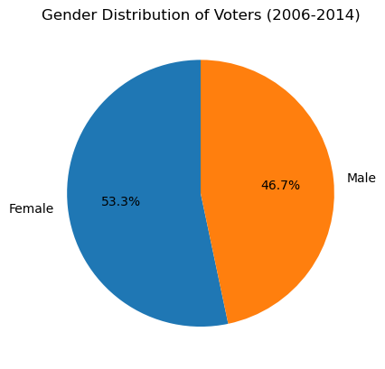

```python
# Calculate the average percentages for the specified time period (2006-2014)
avg_female_percentage = votes_df.loc[votes_df['Year'].between(2006, 2014), 'Female_Percent'].mean()
avg_male_percentage = votes_df.loc[votes_df['Year'].between(2006, 2014), 'Male_Percent'].mean()

# Define the values and labels for the pie chart
list_of_values = [avg_female_percentage, avg_male_percentage]
list_of_labels = ['Female', 'Male']

# Create the pie chart
plt.pie(list_of_values, labels=list_of_labels, autopct='%1.1f%%', startangle=90)

# Add a title to the chart
plt.title("Gender Distribution of Voters (2006-2014)")

# Display the chart
plt.show()
```

*There are 2 questions for the next cell because plotting commands must be in the same cell to work correctly in notebooks.*

**(24)** Create a chart that compares the ratio of votes vs registered for the 4 age groups has changed over time.  
**(25)** Add an appropriate title to the chart.

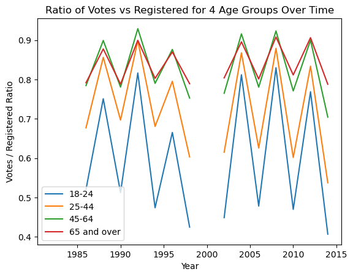

```python
# Define the age groups columns
age_groups = ['18-24', '25-44', '45-64', '65 and over']
registered_columns = [age_group + ' Registered' for age_group in age_groups]
voted_columns = [age_group + ' Voted' for age_group in age_groups]

# Calculate the ratio of votes vs registered for the 4 age groups
votes_vs_registered_ratio = votes_df[voted_columns].div(votes_df[registered_columns].values, axis=0)

# Create the chart
plt.figure()
for age_group, voted_col in zip(age_groups, voted_columns):
    plt.plot(votes_df['Year'], votes_vs_registered_ratio[voted_col], label=age_group)

# Add a title to the chart
plt.title("Ratio of Votes vs Registered for 4 Age Groups Over Time")

# Add legend and labels
plt.legend()
plt.xlabel("Year")
plt.ylabel("Votes / Registered Ratio")

# Display the chart
plt.show()
```